# Презентация по лабораторной работы №9

Операционные системы

Федорова А.И

Российский университет дружбы народов, Москва, Россия

## Цели и задачи

Цель данной лабораторной работы - ознакомление с инструментами поиска файлов и фильтрации текстовых данных, а также приобретение практических навыков по управлению процессами (и заданиями), по проверке использования диска и по обслуживанию файловых систем.

## Задание

- Запись в файл
- Вывод на экран
- Поиск файлов с помощью grep
- Поиск файлов с помощью find
- Запуск в фоновом режиме
- Индентификация процесса
- Завершение процесса
- функция df
- функция du
- Вывод имен всех директорий

## Запись в файл

Проверила, что в файл записались нужные значения с помощью команды сat (рис. @fig:002).

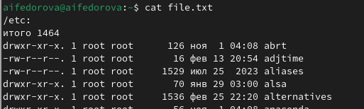

Вывод содержимого файла

## Вывод на экран

Вывела на экран имена всех файлов, имеющих расширение “.conf” с помощью утилиты grep (рис. fig:004).

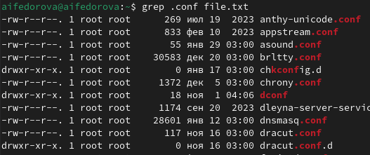

Поиск файлов определенного расширения

Определяю,какие файлы в домашнем каталоге начинаютя с символа “c” с помощью утилиты find, прописываю ей в аргументах домашнюю директорию (тогда вывод относительно корневого каталога, а не домашнего будет), выбираю опцию -name (ищем по имени), и пишу маску, по которой будем искать имя, где * - любое кол-во любых символов, добавляю опцию -print, чтобы мне вывелся результат (рис. fig:006). Но таким образом я получаю информацию даже о файлах из подкаталогов домашнего каталога.

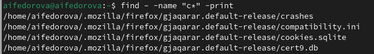

Поиск файлов, начинающихся с определенного элемента

## Запуск в фоновом режиме

Запускаю в фоновом режиме (на это указывает символ &) процесс, который будет записывать в файл logfile (с помощью перенаправления >) файлы, имена которых начинаются с log (рис. fig:009).

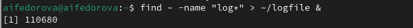

Создание фонового процесса

## Индентификация процесса

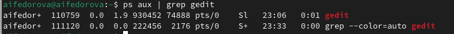

Поиск идентификатора процесса

## Завершение процесса

Прочитала справку команды kill и использую команду kill и идентификатор процесса, чтобы его удалить (рис. fig:013). Заметила, как у меня закрылась программа gedit.

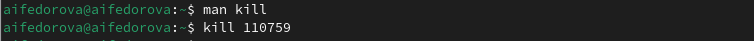

Удаление процесса

## функция df

Прочитала документацию про функции df и du. Теперь я использую утилиту df с файлом сonf.txt. (fig:014). Эта утилита нам нужна, чтобы выяснить, сколько свободного места есть у нашей системы.

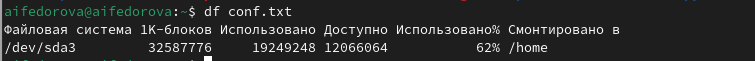

Утилита df

## функция du

Использую утилиту du. Она нужна чтобы просмотреть, сколько места занимают файлы в определенной директории и найти самые большие из них (рис. fig:017).

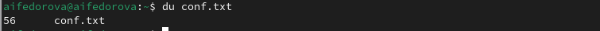

Утилита du

## Вывод имен всех директорий

Вывела имена всех директорий, имеющихся в моем домашнем каталоге, используя аргумент d у утилиты find опции -type, то есть указываю тип файлов, который мне нужен и этот тип Директория (рис.fig:016). Утилита -а позволит увидеть размер всех файлов, а не только диреткорий.

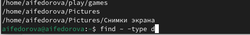

Вывод директорий

## Результаты

В результате данной лабораторной работы я ознакомилась с инструментами поиска файлов и фильтрации текстовых данных, а также приобрела практические навыки по управлению процессами (и заданиями), по проверке использования диска и по обслуживанию файловых систем.

## Итоговый слайд

Спасибо за внимание!